# (Ford Gobike)

## by (Alaa Mehanna)

## Investigation Overview

> This exploration and visualization study mainly focuses on finding the bike usage pattern and customer habit or routine, specifically how user type, time, gender, and age impacts usage of the system.

## Dataset Overview

> This data set includes information about individual rides made in a bike-sharing system covering the greater San Francisco Bay area during february.Visualizations below are created from wrangled and cleaned data to facilitate exploration analysis and help discover usage pattern and rider characteristics.

## (Average Weekday Trip Duration for Customers and Subscribers)

> How does the average trip duration vary in weekdays between customers and subscribers?

> > we have two types of users , we're trying to explore what influences the trip duration for both types each on his own during the weekdays.

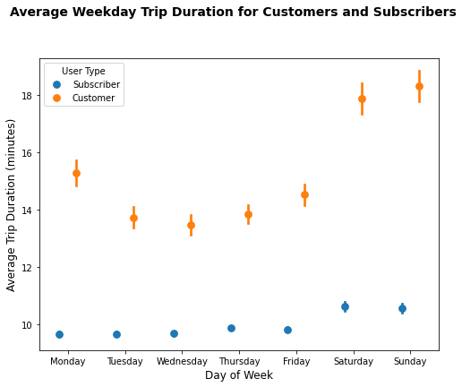

## (Trips count during weekday as per gender)

> Overall the number of Males users overcome the females/other numbers and especially on work days (Mon-Fri) regardless of the user type which might indicate that the service or packages is more encouraging for men.

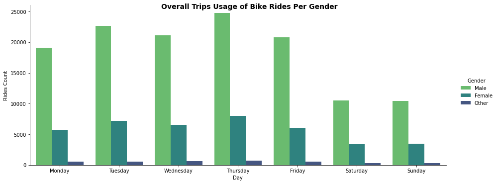

## (Trip Duration Per User Type and Gender)

> In general females take longer on rides than males/others both as subsciber and customers

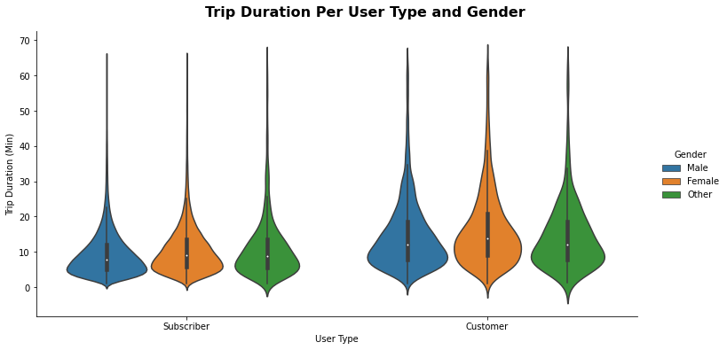